# Introduction to machine learning

*Maxime Sangnier*

Fall, 2019

## Practical session 1: discriminant analysis, logistic regression and boosting

Je n'ai pas compris au départ où il fallait trouver le fichier mllab, alors j'ai recodé toutes les fonctions... les visualisations sont donc peut-être légèrement différentes de celles produites par mllab. Mille excuses pour cela.

1. Discriminant analysis
   - Linear discriminant analysis
   - Quadratic discriminant analysis
   - Fisher discriminant analysis
2. Logistic regression
3. Adaboost

```python
import numpy as np
import matplotlib.pyplot as plt
import seaborn as sns
import sklearn
import sklearn.datasets
from matplotlib import colors
```

```python
cmap = colors.LinearSegmentedColormap(
    'red_blue_classes',
    {'red': [(0, 1, 1), (1, 0.7, 0.7)],
     'green': [(0, 0.7, 0.7), (1, 0.7, 0.7)],
     'blue': [(0, 0.7, 0.7), (1, 1, 1)]})
plt.cm.register_cmap(cmap=cmap)
```

Remark: some plots are adapted from the [scikit-learn documentation](https://scikit-learn.org/stable/auto_examples/classification/plot_lda_qda.html#sphx-glr-auto-examples-classification-plot-lda-qda-py).

# Discriminant analysis

## Linear discriminant analysis

> Write a function that generates a multivariate Gaussian sample of mean $\mu$, covariance defined by $(\sigma_1, \sigma_2, \theta)$ and size $n$. The corresponding numpy array should be of size $(n, 2)$.

> Compute the mean and the empirical covariance of the sample using Numpy routines.

```python
mu = np.array([1, 5])
cov = np.array([[2, 1], [1, 8]])
n = 20
X = np.random.multivariate_normal(mean=mu, cov=cov, size=n)
```

```python
print('Shape: ' + str(X.shape))
print('Empirical mean: ' + str(X.mean(axis = 0)))
print('Empirical covariance: \n' + str(np.cov(X.T)))
```

```
Shape: (20, 2)
Empirical mean: [0.53627846 3.87208198]
Empirical covariance:
[[ 3.18631485  1.63411074]
 [ 1.63411074 12.09190483]]
```

> Generate two multivariate Gaussian samples of size $n_1 = n_2 = 50$ with different means and equal covariance matrices. Plot both samples with different markers.

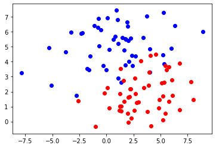

```python
# Answer
mu1 = np.array([1, 5])
mu2 = np.array([4, 2])
cov = np.array([[8, 1], [1, 2]])
n1 = 50
n2 = 50
X1 = np.random.multivariate_normal(mean=mu1, cov=cov, size=n1)
X2 = np.random.multivariate_normal(mean=mu2, cov=cov, size=n2)
plt.scatter(x=X1[:,0], y=X1[:,1], c='b')
plt.scatter(x=X2[:,0], y=X2[:,1], c='r')
plt.show()
```

> Based on the following code, implement a linear discriminant classifier, taking as parameters an $n \times 2$ Numpy array as data and a size-$n$ array of labels.

```python
from sklearn.base import BaseEstimator
from sklearn.discriminant_analysis import LinearClassifierMixin

class LDA(BaseEstimator, LinearClassifierMixin):
    """
        LDA classifier for two classes.
    """
    def __init__(self, prior=None):
        """
            prior: wether to use prior in the intercept. Default is false.
        """
        self.prior = prior

    def fit(self, X, y):
        X1 = X[np.where(y==1)]
        X2 = X[np.where(y==-1)]
        mu_pos = np.mean(X1, axis=0)
        mu_neg = np.mean(X2, axis=0)
        self.means_ = np.array([mu_pos, mu_neg])
        pi = self.prior if self.prior else 0.5
        cov = pi*np.cov(X1.T) + (1-pi)*np.cov(X2.T)
        cov_inv = np.linalg.inv(cov)
        self.w = np.dot(cov_inv, mu_pos-mu_neg)
        self.b = np.log(pi / (1-pi)) + 0.5*(np.dot(mu_neg.T, np.dot(cov_inv, mu_neg)) - np.dot(mu_pos.T, np.dot(cov_inv, mu_pos)))

    def decision_function(self, X):
        return np.dot(X, self.w) + self.b

    def predict(self, X):
        return 2*(self.decision_function(X) > 0) - 1

    def predict_proba(self, X):
        return np.array(list(map(lambda x: [1 / (1 + np.exp(x)), np.exp(x) / (1 + np.exp(x))], lda.decision_function(X))))

    def regret(self, X, y):
        return np.sum(np.abs(self.predict(X) - y)) / len(X)
```

> Create the Numpy arrays `X` and `y` based on the samples generated previously and fit a linear discriminant classifier. Plot the data along with the classifier frontiere.

```python
X = np.concatenate((X1, X2))
y = np.array([1]*n1 + [-1]*n2)
lda = LDA()
lda.fit(X, y)
```

```python
def plot_decision_clf(clf, X, y, plot_bisector=False):
    plt.figure(figsize=(6, 5))
    plt.scatter(x=X[np.where(y==1)][:,0], y=X[np.where(y==1)][:,1], c='b')
    plt.scatter(x=X[np.where(y==-1)][:,0], y=X[np.where(y==-1)][:,1], c='r')

    nx, ny = 200, 100
    xy_min = np.min(X)
    xy_max = np.max(X)
    plt.xlim([xy_min, xy_max])
    plt.ylim([xy_min, xy_max])
    xx, yy = np.meshgrid(np.linspace(xy_min, xy_max, nx),
                         np.linspace(xy_min, xy_max, ny))
    Z = clf.predict_proba(np.c_[xx.ravel(), yy.ravel()])
    Z = Z[:, 1].reshape(xx.shape)
    plt.pcolormesh(xx, yy, Z, cmap='red_blue_classes',
                   norm=colors.Normalize(0., 1.), zorder=0)
    plt.colorbar()
    plt.contour(xx, yy, Z, [0.5], linewidths=2., colors='white')

    if hasattr(clf, "means_"):
        plt.plot(clf.means_[0][0], clf.means_[0][1], '*', color='white', markersize=15, markeredgecolor='grey')
        plt.plot(clf.means_[1][0], clf.means_[1][1], '*', color='white', markersize=15, markeredgecolor='grey')

        if plot_bisector:
            mu1_exp = clf.means_[0]
            mu2_exp = clf.means_[1]
            x1 = [(mu1_exp[1] - mu2_exp[1])*t + 0.5*(mu2_exp[0] + mu1_exp[0]) for t in range(-100, 200, 100)]
            x2 = [(mu2_exp[0] - mu1_exp[0])*t + 0.5*(mu2_exp[1] + mu1_exp[1]) for t in range(-100, 200, 100)]
            plt.plot(x1, x2, label='bisector of the class centers')
            plt.legend()

    plt.show()
```

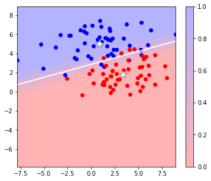

```python
plot_decision_clf(lda, X, y)
```

> Compare the result of [scikit-learn LDA](http://scikit-learn.org/stable/modules/generated/sklearn.discriminant_analysis.LinearDiscriminantAnalysis.html#sklearn.discriminant_analysis.LinearDiscriminantAnalysis) (decision function and frontiere).

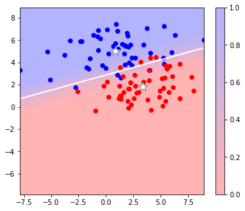

```python
lda_sk = sklearn.discriminant_analysis.LinearDiscriminantAnalysis()
lda_sk.fit(X, y)

plot_decision_clf(lda_sk, X, y)
# add legend
```

## Quadratic discriminant analysis

> Analyze the behavior of LDA and [QDA](http://scikit-learn.org/stable/modules/generated/sklearn.discriminant_analysis.QuadraticDiscriminantAnalysis.html#sklearn.discriminant_analysis.QuadraticDiscriminantAnalysis) when it is faced to anisotropic Gaussian samples (in particular, check if the frontiere is the bisector of the line segment for which the extremities are both class centers), and then to Gaussian samples with different covariance matrices.

On vérifie que la frontière n'est pas égale à la bissectrice, car les données sont anisotropiques.

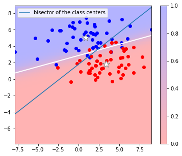

```python
plot_decision_clf(lda, X, y, plot_bisector=True)
```

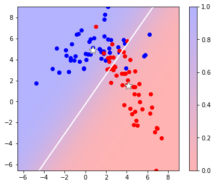

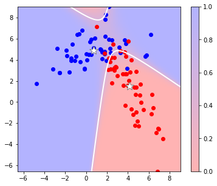

```python
mu1 = np.array([1, 5])
mu2 = np.array([4, 2])
cov1 = np.array([[8, 1], [1, 2]])
cov2 = np.array([[2, -3], [-3, 8]])
n1 = 50
n2 = 50
X1 = np.random.multivariate_normal(mean=mu1, cov=cov1, size=n1)
X2 = np.random.multivariate_normal(mean=mu2, cov=cov2, size=n2)
Xquad = np.concatenate((X1, X2))
yquad = np.array([1]*n1 + [-1]*n2)

lda_sk.fit(Xquad, yquad)
qda_sk = sklearn.discriminant_analysis.QuadraticDiscriminantAnalysis()
qda_sk.fit(Xquad, yquad)

plot_decision_clf(lda_sk, Xquad, yquad)
plot_decision_clf(qda_sk, Xquad, yquad)
```

## Fisher discriminant analysis

> Implement the Fisher discriminant analysis based on the following code. In practice, what is the difference between LDA and FisherDA?

```python
class FisherDA(BaseEstimator, LinearClassifierMixin):
    """
        Fisher discriminant analysis for two classes.
    """
    def fit(self, X, y):
        X1 = X[np.where(y==1)]
        X2 = X[np.where(y==-1)]
        mu_pos = np.mean(X1, axis=0)
        mu_neg = np.mean(X2, axis=0)
        self.means_ = np.array([mu_pos, mu_neg])
        pi = len(X1) / len(X)
        cov = pi*np.cov(X1.T) + (1-pi)*np.cov(X2.T)
        cov_inv = np.linalg.inv(cov)
        self.w = np.dot(cov_inv, mu_pos-mu_neg)

        # find the optimal b
        proj = np.dot(X, lda.w)
        np.array(list(map(lambda x: 1 if x else -1, proj > 0)))
        self.b = - proj[np.argmin([np.sum(np.abs(2*(proj - b > 0)-1 - y)) for b in proj])]

    def decision_function(self, X):
        return np.dot(X, self.w) + self.b

    def predict(self, X):
        return 2*(self.decision_function(X) > 0) - 1

    def predict_proba(self, X):
        return np.array(list(map(lambda x: [1 / (1 + np.exp(x)), np.exp(x) / (1 + np.exp(x))], lda.decision_function(X))))

    def regret(self, X, y):
        return np.sum(np.abs(self.predict(X) - y)) / len(X)
```

En pratique, la différence entre la LDA et la FDA est qu'on doit choisir b dans le cas de la FDA. Ici on prend b optimal donc on obtient un regret inférieur pour la FDA.

```python
fda = FisherDA()
fda.fit(X, y)
print('Intersect for FDA: ' + str(fda.b) + ' ; intersect for LDA: ' + str(lda.b))
print('Regret for FDA: ' + str(fda.regret(X, y)) + ' ; regret for LDA: ' + str(lda.regret(X, y)))
```

```
Intersect for FDA: -5.070335158913725 ; intersect for LDA: -6.271609677607193
Regret for FDA: 0.12 ; regret for LDA: 0.18
```

# Logistic regression

> We consider that $X|Y=1 \sim \mathcal N(0, I)$ and $X|Y=-1 \sim 0.5 \mathcal N\left(\begin{pmatrix} 5 \\ 3 \end{pmatrix}, I\right) + 0.5 \mathcal N\left(\begin{pmatrix} 8 \\ 9 \end{pmatrix}, I\right)$ (non-Gaussian class). Compare LDA and [logistic regression](http://scikit-learn.org/stable/modules/generated/sklearn.linear_model.LogisticRegression.html).

```python
lr = sklearn.linear_model.LogisticRegression(solver="liblinear")
```

Les deux méthodes donnent des résultats similaires, la régression logistique parvient mieux à séparer les classes. Comme une des classes n'est pas gaussienne, l'hypothèse qui sous-tend la LDA ne tient plus.

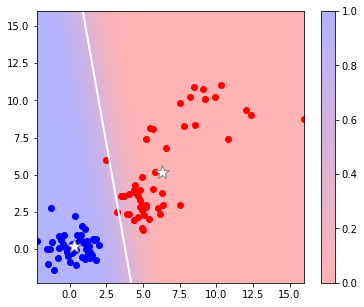

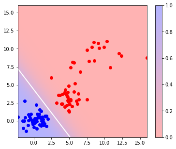

```python
n1 = 50
n2 = 50
i2 = np.identity(2)
X1 = np.random.multivariate_normal(mean=[0, 0], cov=i2, size=n1)
r = np.random.randint(0, 51)
X2 = np.concatenate((np.random.multivariate_normal(mean=[5, 3], cov=i2, size=r), np.random.multivariate_normal(mean=[8, 9], cov=cov, size=n2-r)))
X = np.concatenate((X1, X2))
y = np.array([1]*n1 + [-1]*n2)

lda_sk.fit(X, y)
plot_decision_clf(lda_sk, X, y)

lr.fit(X, y)
plot_decision_clf(lr, X, y)
```

> What about with this dataset (class $-1$ is Gaussian but with an outlier)?

On observe que la LDA est beaucoup plus sensible au point outlier que la régression logistique.

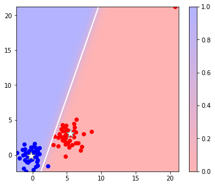

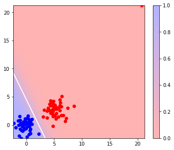

```python
# Dataset
n1 = 50
X1 = np.random.multivariate_normal(mean=[0, 0], cov=i2, size=n1)
X2 = np.random.multivariate_normal(mean=[5, 3], cov=i2, size=49)
X3 = np.random.multivariate_normal(mean=[20, 20], cov=i2, size=1).reshape(1, -1)

X = np.r_[X1, X2, X3]
y = np.r_[np.ones(X1.shape[0]), -np.ones(X2.shape[0]), -np.ones(X3.shape[0])]

lda_sk.fit(X, y)
plot_decision_clf(lda_sk, X, y)

lr.fit(X, y)
plot_decision_clf(lr, X, y)
```

# Adaboost

> We consider the dataset defined below.

```python
from mllab import gaussian_sample
```

[output not shown]

```python
# Dataset
X1 = gaussian_sample(mu=[0, 0], sigma1=10, theta=np.pi/6)
X2 = gaussian_sample(mu=[5, 3], sigma1=3, sigma2=10, theta=np.pi/6, n=50)
X3 = gaussian_sample(mu=[-5, -2], sigma1=3, sigma2=10, theta=np.pi/10, n=50)

X = np.r_[X1, X2, X3]
Y = np.r_[np.ones(X1.shape[0]), -np.ones(X2.shape[0]), -np.ones(X3.shape[0])]
```

> Fit an [Adaboost](http://scikit-learn.org/stable/modules/generated/sklearn.ensemble.AdaBoostClassifier.html) classifier with $100$ weak learners and the algorithm SAMME. Map the classifier regions on a figure.

```python
from matplotlib import cm

def map_regions(clf, data=None, num=50):
    """
        Map the regions f(x)=1…K of the classifier clf within the same range as the one
        of the data.
        Input:
            clf: classifier with a method predict
            data: input data (X)
            num: discretization parameter
    """
    xmin, ymin = data.min(axis=0)
    xmax, ymax = data.max(axis=0)
    x, y = np.meshgrid(np.linspace(xmin, xmax, num), np.linspace(ymin, ymax))
    z = clf.predict(np.c_[x.ravel(), y.ravel()]).reshape(x.shape)
    zmin, zmax = z.min(), z.max()
    plt.imshow(z, origin='lower', interpolation="nearest",
               extent=[xmin, xmax, ymin, ymax], cmap=cm.coolwarm,
              alpha=0.3)
```

[figure not shown]

```python
import sklearn.ensemble
ada = sklearn.ensemble.AdaBoostClassifier(n_estimators=100, algorithm='SAMME')
ada.fit(X, Y)
map_regions(ada, data=X)
```

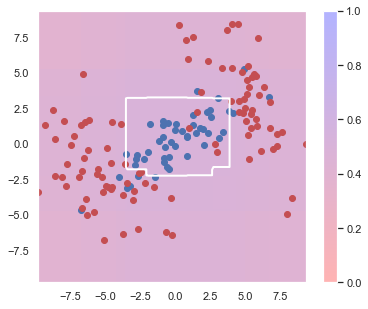

```python
plot_decision_clf(ada, X, Y)
```

> Plot on a new figure the estimator errors (attribute `estimator\_errors\_`). What do you observe?

Les erreurs des estimateurs semblent converger vers 0.5, à mesure que le problème de classification devient plus difficile à résoudre.

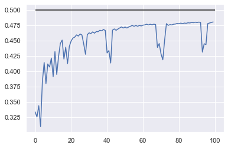

```python
plt.plot(ada.estimator_errors_)
plt.hlines(y=0.5, xmin=0, xmax=100)
plt.show()
```

> Load the [dataset digits](http://scikit-learn.org/stable/modules/generated/sklearn.datasets.load_digits.html#sklearn.datasets.load_digits). How many observations, covariates and classes has it? [Split](http://scikit-learn.org/stable/modules/generated/sklearn.model_selection.train_test_split.html) the dataset into two equally sized subsets (one for training, the other for testing, i.e. estimating the true error).

```python
data, target = sklearn.datasets.load_digits(return_X_y=True)
print('Number of observations: %d \nNumber of covariates: %d \nNumber of classes: %d' % (data.shape[0], data.shape[1], len(np.unique(target))))

data_train = data[: data.shape[0]//2]
target_train = target[: data.shape[0]//2]
data_test = data[data.shape[0]//2 :]
target_test = target[data.shape[0]//2 :]
```

```
Number of observations: 1797
Number of covariates: 64
Number of classes: 10
```

> Plot the train and test errors of both algorithms SAMME and SAMME.R with respect to the number of iterations (from 1 to 200) for the dataset digits. For this purpose, use [`DecisionTreeClassifier(max_depth=5)`](http://scikit-learn.org/stable/modules/generated/sklearn.tree.DecisionTreeClassifier.html) as base learner.

```python
ada_digits = sklearn.ensemble.AdaBoostClassifier(base_estimator=sklearn.tree.DecisionTreeClassifier(max_depth=5),
                                                 algorithm='SAMME',
                                                 n_estimators=200)
ada_digits_R = sklearn.ensemble.AdaBoostClassifier(base_estimator=sklearn.tree.DecisionTreeClassifier(max_depth=5),
                                                 algorithm='SAMME.R',
                                                 n_estimators=200)
ada_digits.fit(data_train, target_train)
ada_digits_R.fit(data_train, target_train)
```

```
AdaBoostClassifier(algorithm='SAMME.R',
                   base_estimator=DecisionTreeClassifier(class_weight=None,
                                                         criterion='gini',
                                                         max_depth=5,
                                                         max_features=None,
                                                         max_leaf_nodes=None,
                                                         min_impurity_decrease=0.0,
                                                         min_impurity_split=None,
                                                         min_samples_leaf=1,
                                                         min_samples_split=2,
                                                         min_weight_fraction_leaf=0.0,
                                                         presort=False,
                                                         random_state=None,
                                                         splitter='best'),
                   learning_rate=1.0, n_estimators=200, random_state=None)
```

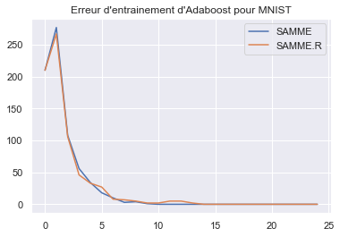

```python
plt.plot(range(25), [np.sum(yhat-target_train !=0) for yhat in ada_digits.staged_predict(data_train)][:25], label='SAMME')
plt.plot(range(25), [np.sum(yhat-target_train !=0) for yhat in ada_digits_R.staged_predict(data_train)][:25], label='SAMME.R')
plt.title("Erreur d'entrainement d'Adaboost pour MNIST")
plt.legend()
plt.show()
```

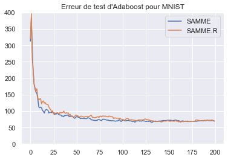

```python
plt.ylim([0, 400])
plt.plot(range(200), [np.sum(yhat-target_test !=0) for yhat in ada_digits.staged_predict(data_test)], label='SAMME')
plt.plot(range(200), [np.sum(yhat-target_test !=0) for yhat in ada_digits_R.staged_predict(data_test)], label='SAMME.R')
plt.title("Erreur de test d'Adaboost pour MNIST")
plt.legend()
plt.show()
```